# UNIT13C：類別模型、預測機率與商業決策

預測與決策

第十一組

2019-05-26 16:34:08

```r
pacman::p_load(caTools, ggplot2, dplyr)
D = read.csv("data/quality.csv")  # Read in dataset
set.seed(88)
split = sample.split(D$PoorCare, SplitRatio = 0.75)  # split vector
TR = subset(D, split == TRUE)
TS = subset(D, split == FALSE)
glm1 = glm(PoorCare ~ OfficeVisits + Narcotics, TR, family=binomial)
summary(glm1)
```

[output not shown]

### 【A】從預測到決策

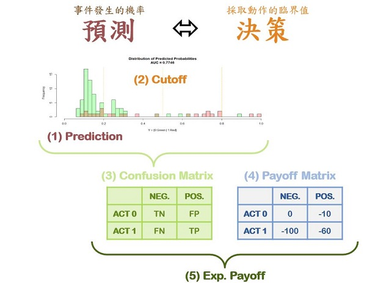

Fig 13.3 - 從預測到決策

### 【B】預測機率分佈 (DPP)

因為這個資料集很小，我們使用全部的資料來做模擬 (通常我們是使用測試資料集)

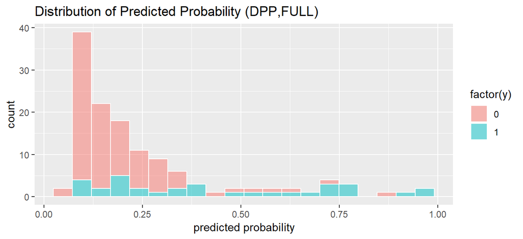

```r
pred = predict(glm1, D, type="response")
y = D$PoorCare
data.frame(pred, y) %>%
  ggplot(aes(x=pred, fill=factor(y))) +
  geom_histogram(bins=20, col='white', position="stack", alpha=0.5) +
  ggtitle("Distribution of Predicted Probability (DPP,FULL)") +
  xlab("predicted probability")
```

### 【C】試算期望報酬

**報酬矩陣 Payoff Matrix**

- TN: NoAction, GoodCare; 沒事
- FN: NoAction, PoorCare; 風險成本很高
- FP: Action, GoodCare; 預防成本
- TP: Action, PoorCare; 預防成本 + 降低後的風險成本

```r
payoff = matrix(c(0,-100,-10,-50),2,2)
payoff
```

```
     [,1] [,2]
[1,]    0  -10
[2,] -100  -50
```

**期望報酬 Expected Payoff**

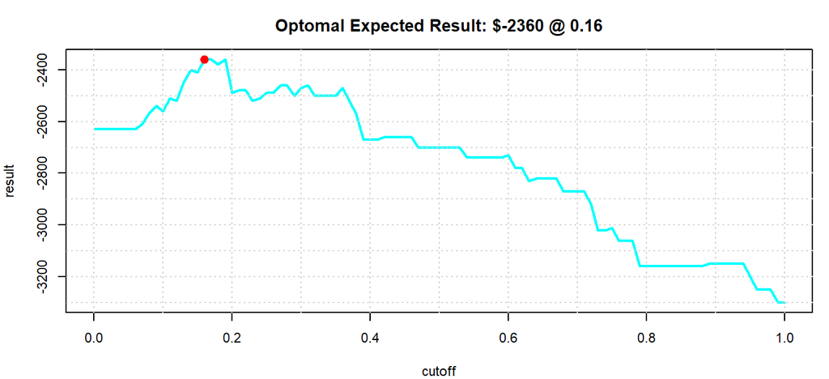

```r
cutoff = seq(0, 1, 0.01)
result = sapply(cutoff, function(p) sum(
  table(factor(y==1, c(F,T)), factor(pred>p, c(F,T))) # confusion matrix
  * payoff ))
i = which.max(result)
par(cex=0.7, mar=c(4,4,3,1))
plot(cutoff, result, type='l', col='cyan', lwd=2, main=sprintf(
  "Optomal Expected Result: $%d @ %.2f",result[i],cutoff[i]))
abline(v=seq(0,1,0.1),h=seq(-6000,0,100),col='lightgray',lty=3)
points(cutoff[i], result[i], pch=20, col='red', cex=2)
```

### 【D】策略模擬

🗿 練習：  
執行`Sim13.R`，先依預設的報酬矩陣回答下列問題：  
【A】 最佳臨界機率是？ 它所對應的期望報酬是多少？  
【B】 什麼都不做時，臨界機率和期望報酬各是多少？  
【C】 每位保戶都做時，臨界機率和期望報酬各是多少？  
【D】 以上哪一種做法期的望報酬比較高？  
【E】 在所有的商務情境都是這種狀況嗎？  
藉由調整報酬矩陣：  
【F】 模擬出「全不做」比「全做」還要好的狀況  
【G】 並舉出一個會發生這種狀況的商務情境  
有五種成本分別為`$5, $10, $15, $20, $30`的介入方法，它們分別可以將風險成本從`$100`降低到`$70, $60, $50, $40, $25` …  
【H】 它們的最佳期望報酬分別是多少？  
【I】 哪一種介入方法的最佳期望報酬是最大的呢？

**使用`manipulate`套件做策略模擬**

```r
library(manipulate)
manipulate({
  payoff = matrix(c(TN,FN,FP,TP),2,2)
  cutoff = seq(0, 1, 0.01)
  result = sapply(cutoff, function(p) sum(
    table(factor(y==1, c(F,T)), factor(pred>p, c(F,T))) # confusion matrix
    * payoff ))
  i = which.max(result)
  par(cex=0.7)
  plot(cutoff, result, type='l', col='cyan', lwd=2, main=sprintf(
    "Optomal Expected Result: $%d @ %.2f",result[i],cutoff[i]))
  abline(v=seq(0,1,0.1),h=seq(-10000,0,100),col='lightgray',lty=3)
  points(cutoff[i], result[i], pch=20, col='red', cex=2)
  },
  TN = slider(-100,0,   0,step=5),
  FN = slider(-100,0,-100,step=5),
  FP = slider(-100,0, -10,step=5),
  TP = slider(-100,0, -50,step=5)
  )
```

### Ans.

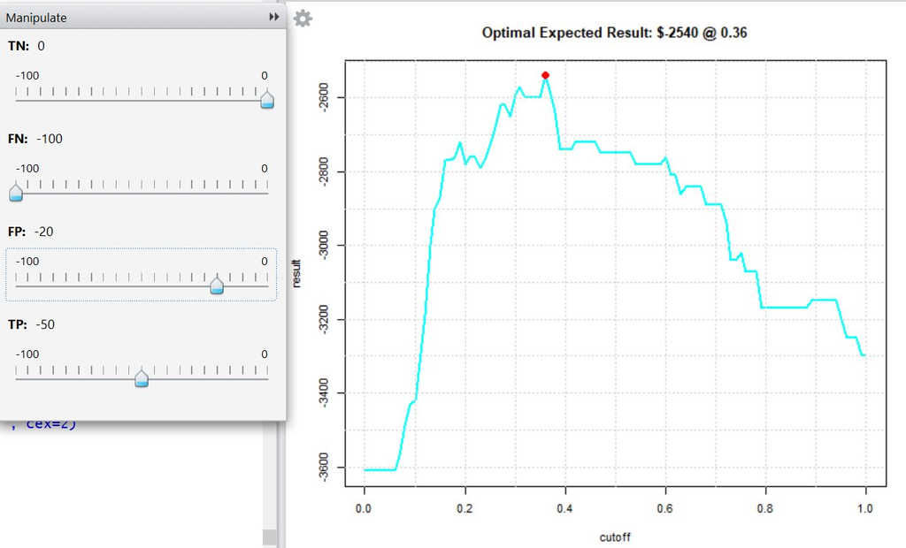

(2)當風險成本下降為$75

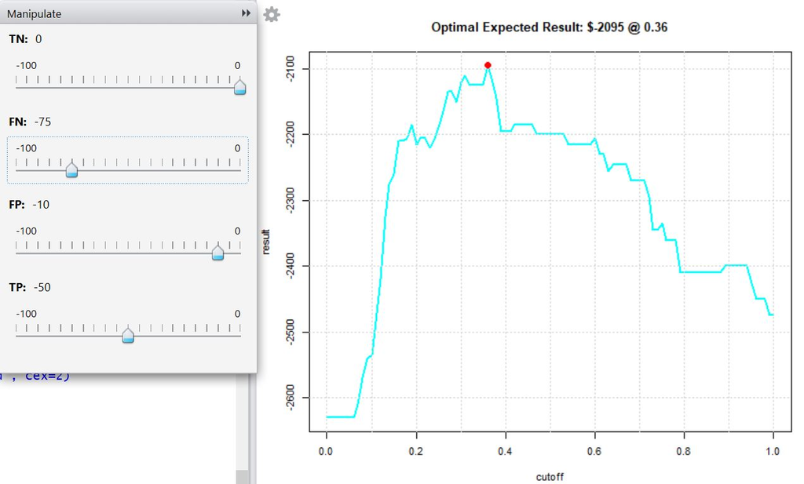

(3)當goodcare能獲利$10

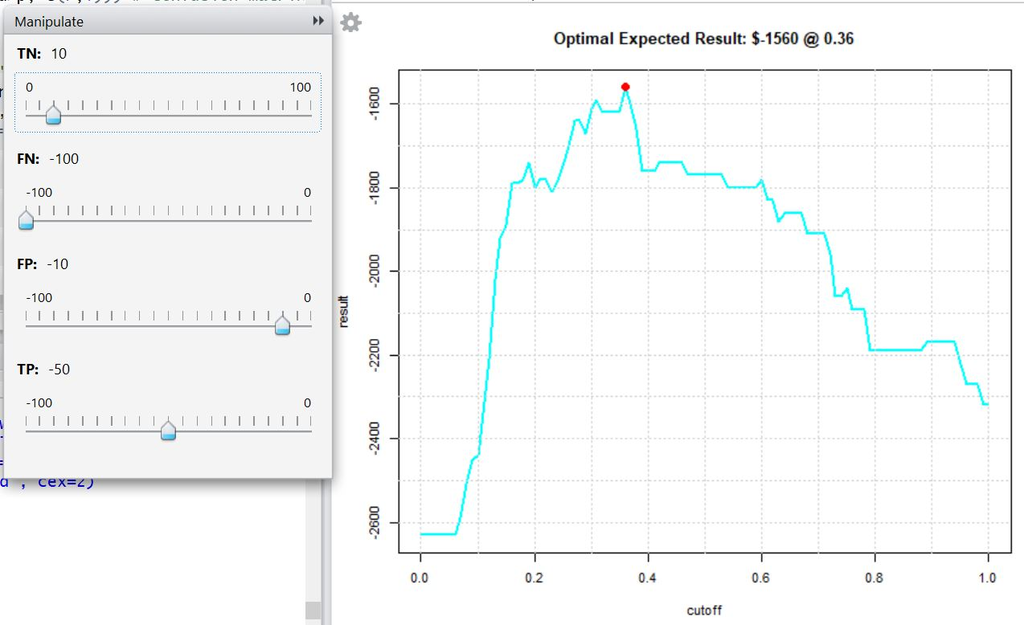

(4)當預防後的風險成本未降低很多$75(預防成本$10+預防後的風險成本$65)

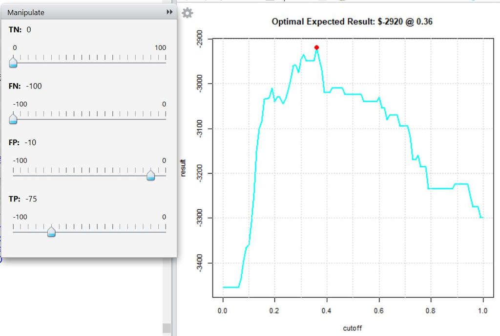

【G】 會發生這種狀況的商務情境：  
(1) 預防成本提高(FP)  
(2) 風險成本降低(FN)  
(3) 可從goodcare保戶中獲利(TN)  
(4) 採取預防後的風險成本未降低很多(TP)  
**有五種成本分別為`$5, $10, $15, $20, $30`的介入方法，它們分別可以將風險成本從`$100`降低到`$70, $60, $50, $40, $25` …**  
【H】 它們的最佳期望報酬分別是

```r
prevent_cost = c(5, 10, 15, 20, 30)
risk_cost = c(75, 70, 65, 60, 55)
new_cutoff = c(0.16, 0.36, 0.36, 0.36, 0.36)
new_payoff = c(-2830, -2830, -2775, -2720, -2700)
new_data = data.frame(prevent_cost, risk_cost, new_cutoff, new_payoff)
new_data
```

```
  prevent_cost risk_cost new_cutoff new_payoff
1            5        75       0.16      -2830
2           10        70       0.36      -2830
3           15        65       0.36      -2775
4           20        60       0.36      -2720
5           30        55       0.36      -2700
```

【I】 成本為30的介入方法最佳期望報酬是最大的(-2700)。